# NYPD Shooting Incident Data

2022-09-10

## Description of Data

The NYPD Shooting Incident data set is a comprehensive list of shooting incidents that occurred in NYC starting in 2006 through the end of the previous calendar year. Each incident includes information on the location and time of the event, as well as victim and suspect demographic descriptions.

## Import Data

```r
data_url <- 'https://data.cityofnewyork.us/api/views/833y-fsy8/rows.csv?accessType=DOWNLOAD'
nypd_data <- read_csv(data_url)
```

## Initial Summary of Data

```r
summary(nypd_data)
```

```
##   INCIDENT_KEY        OCCUR_DATE         OCCUR_TIME           BORO
##  Min.   :  9953245   Length:25596       Length:25596      Length:25596
##  1st Qu.: 61593633   Class :character   Class1:hms        Class :character
##  Median : 86437258   Mode  :character   Class2:difftime   Mode  :character
##  Mean   :112382648                      Mode  :numeric
##  3rd Qu.:166660833
##  Max.   :238490103
##
##     PRECINCT      JURISDICTION_CODE LOCATION_DESC      STATISTICAL_MURDER_FLAG
##  Min.   :  1.00   Min.   :0.0000    Length:25596       Mode :logical
##  1st Qu.: 44.00   1st Qu.:0.0000    Class :character   FALSE:20668
##  Median : 69.00   Median :0.0000    Mode  :character   TRUE :4928
##  Mean   : 65.87   Mean   :0.3316
##  3rd Qu.: 81.00   3rd Qu.:0.0000
##  Max.   :123.00   Max.   :2.0000
##                   NA's   :2
##  PERP_AGE_GROUP       PERP_SEX          PERP_RACE         VIC_AGE_GROUP
##  Length:25596       Length:25596       Length:25596       Length:25596
##  Class :character   Class :character   Class :character   Class :character
##  Mode  :character   Mode  :character   Mode  :character   Mode  :character
##
##
##
##
##    VIC_SEX            VIC_RACE           X_COORD_CD        Y_COORD_CD
##  Length:25596       Length:25596       Min.   : 914928   Min.   :125757
##  Class :character   Class :character   1st Qu.:1000011   1st Qu.:182782
##  Mode  :character   Mode  :character   Median :1007715   Median :194038
##                                        Mean   :1009455   Mean   :207894
##                                        3rd Qu.:1016838   3rd Qu.:239429
##                                        Max.   :1066815   Max.   :271128
##
##     Latitude       Longitude        Lon_Lat
##  Min.   :40.51   Min.   :-74.25   Length:25596
##  1st Qu.:40.67   1st Qu.:-73.94   Class :character
##  Median :40.70   Median :-73.92   Mode  :character
##  Mean   :40.74   Mean   :-73.91
##  3rd Qu.:40.82   3rd Qu.:-73.88
##  Max.   :40.91   Max.   :-73.70
##
```

## Data Transformation

```r
nypd_data <- nypd_data %>% rename(Borough = 'BORO') %>% #change name from BORO to Borough
  mutate(OCCUR_DATE = mdy(OCCUR_DATE)) %>% # convert date column entires to a date objects
  select(-c(PRECINCT, JURISDICTION_CODE, LOCATION_DESC, STATISTICAL_MURDER_FLAG, X_COORD_CD, Y_COORD_CD, Lon_Lat)) # remove excess columns
summary(nypd_data)
```

```
##   INCIDENT_KEY         OCCUR_DATE          OCCUR_TIME         Borough
##  Min.   :  9953245   Min.   :2006-01-01   Length:25596      Length:25596
##  1st Qu.: 61593633   1st Qu.:2009-05-10   Class1:hms        Class :character
##  Median : 86437258   Median :2012-08-26   Class2:difftime   Mode  :character
##  Mean   :112382648   Mean   :2013-06-13   Mode  :numeric
##  3rd Qu.:166660833   3rd Qu.:2017-07-01
##  Max.   :238490103   Max.   :2021-12-31
##  PERP_AGE_GROUP       PERP_SEX          PERP_RACE         VIC_AGE_GROUP
##  Length:25596       Length:25596       Length:25596       Length:25596
##  Class :character   Class :character   Class :character   Class :character
##  Mode  :character   Mode  :character   Mode  :character   Mode  :character
##
##
##
##    VIC_SEX            VIC_RACE            Latitude       Longitude
##  Length:25596       Length:25596       Min.   :40.51   Min.   :-74.25
##  Class :character   Class :character   1st Qu.:40.67   1st Qu.:-73.94
##  Mode  :character   Mode  :character   Median :40.70   Median :-73.92
##                                        Mean   :40.74   Mean   :-73.91
##                                        3rd Qu.:40.82   3rd Qu.:-73.88
##                                        Max.   :40.91   Max.   :-73.70
```

There is missing demographic data for the perpetrator, which makes sense because they may not have been caught or identified. This missing date could be omitted with the following code if that information was needed in the analysis.

```r
#sum(is.na(nypd_data))
#nypd_data <- na.omit(nypd_data)
```

This code is not going to be used because this data exploration and analysis will focus on the specific boroughs and associated incident occurrences.

## Visualize the Data

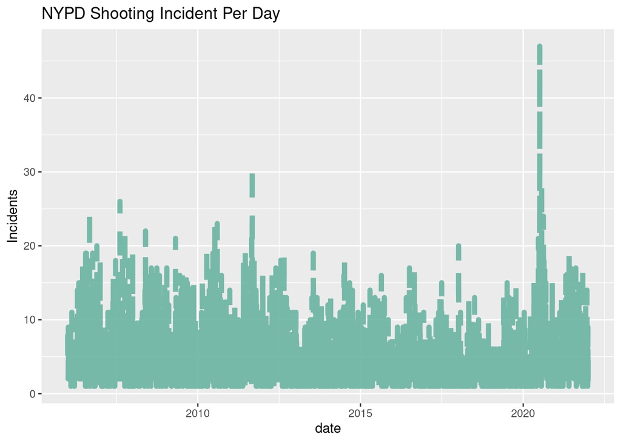

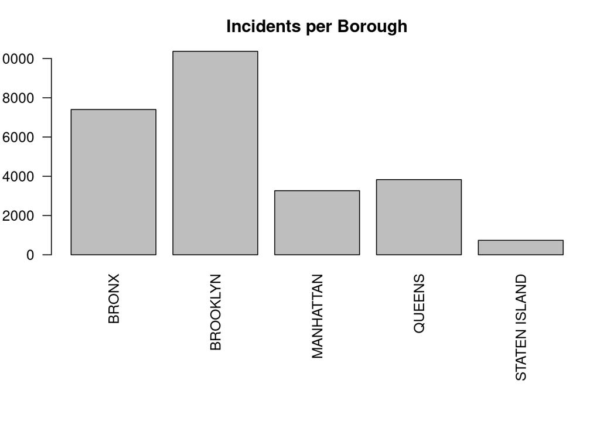

It looks like Brooklyn has the most reported incidents, and the following chart shows how many incidents per day are occuring there.

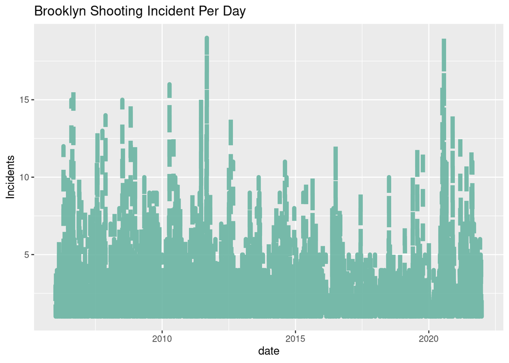

Like the graph of the entire city, there is not a drastic increase or decrease in the number of daily occurrences through the time period capture in this data set.

## Analyze the Data

While there is not a drastic increase or decrease in the number of daily incidents over a long period of time, there do seem to be wide variations during smaller periods of time. Because of that variation it would be interesting to see the daily average incidents occuring in each borough.

```
##    Borough            OCCUR_DATE               n
##  Length:12239       Min.   :2006-01-01   Min.   : 1.000
##  Class :character   1st Qu.:2009-08-04   1st Qu.: 1.000
##  Mode  :character   Median :2013-05-06   Median : 1.000
##                     Mean   :2013-09-14   Mean   : 2.091
##                     3rd Qu.:2017-09-26   3rd Qu.: 3.000
##                     Max.   :2021-12-31   Max.   :19.000
```

```
## # A tibble: 5 × 2
##   Borough       daily_average
##   <chr>                 <dbl>
## 1 BRONX                  2.20
## 2 BROOKLYN               2.53
## 3 MANHATTAN              1.66
## 4 QUEENS                 1.70
## 5 STATEN ISLAND          1.32
```

## Conculsions and Biases

In conclusion, the number of incidents reported in NYC has not dramatically increased or decreased throughout and since 2006. That same state holds for the specific boroughs as well, although the different boroughs do not have the same leave of report incidents. For example Brooklyn has the highest average reported incidents compared to the other four boroughs.

The analysis presented here does not include any other the demographic data, which would be the most likely aspect of this data set to introduce bias. However personal knowledge of different boroughs and stereotypes associated with them could lead to no further exploration of the data. As stated above Brooklyn had the highest average number of reported incidents, and if someone had heard that Brooklyn wasn’t save because of a certain group of people who live there or any other reason, that prior knowledge might stop further analysis because the current analysis confirmed a preconceived notion. This would be inappropriate because all reasons for the higher reported incidents would not be explored, therefore making the results inaccurate.